# maftools

### maftools - A package to process and visualize maf files.

With advances in Cancer Genomics, maf format is being widley accepted and used to store variants detected. [The Cancer Genome Atlas](http://cancergenome.nih.gov) Project has seqenced over 30 different cancers with sample size of each cancer type being over 200. The [resulting data](https://wiki.nci.nih.gov/display/TCGA/TCGA+MAF+Files) consisting of genetic variants is stored in the form of Mutation Annotation Format. This package attempts to summerize such files either from TCGA or in house studies by providing various functions for plotting and parsing.

#### Installation:

`library("devtools")`

`install_github(repo = "PoisonAlien/maftools")`

#### Dependencies:

data.table, ggplot2, plyr, reshape, [cometExactTest](https://cran.r-project.org/web/packages/cometExactTest/)

Bioconductor packages: [ComplexHeatmap](https://bioconductor.org/packages/release/bioc/html/ComplexHeatmap.html), [VariantAnnotation](https://bioconductor.org/packages/release/bioc/html/VariantAnnotation.html) and [Biostrings](https://bioconductor.org/packages/release/bioc/html/Biostrings.html).

## Reading MAF file

First we read maf file using fuction `read.maf` which also summarises variants by various ways and sorts them. It returns a list of `data.frame`s which can be accessed easily.

```r
require(maftools)
#read TCGA maf file for LAML
laml.maf = system.file('extdata', 'tcga_laml.maf', package = 'maftools')
laml = read.maf(maf = laml.maf, removeSilent = T, useAll = F)
```

```
## reading maf..
## Using only Somatic variants from Mutation_Status. Switch on useAll to include everything.
## removed 622 silent variants.
## Summerizing..
## Frequently mutated genes..
## Creating oncomatrix..
## Sorting..
## Done !
```

MAF file is summarized in various ways which can easily accessed. For example..

```r
#Based on Variant_Classification
laml$variant.classification.summary
```

```
##      Tumor_Sample_Barcode Frame_Shift_Del Frame_Shift_Ins In_Frame_Del
##   1:         TCGA.AB.2802               1               2            0
##   2:         TCGA.AB.2803               1               0            0
##   3:         TCGA.AB.2804               0               1            0
##   4:         TCGA.AB.2805               0               1            0
##   5:         TCGA.AB.2806               0               2            0
##  ---
## 192:         TCGA.AB.3007               0               0            0
## 193:         TCGA.AB.3008               0               0            0
## 194:         TCGA.AB.3009               1               5            0
## 195:         TCGA.AB.3011               0               1            0
## 196:         TCGA.AB.3012               1               1            0
##      In_Frame_Ins Missense_Mutation Nonsense_Mutation Splice_Site
##   1:            0                 8                 0           0
##   2:            0                12                 1           0
##   3:            0                 7                 1           0
##   4:            0                10                 1           0
##   5:            0                15                 0           0
##  ---
## 192:            1                 5                 0           1
## 193:            2                 2                 0           0
## 194:            1                28                 2           1
## 195:            0                 5                 0           0
## 196:            0                 6                 0           1
```

```r
#Based on frequcy of mutated geens
laml$gene.summary
```

```
##       Hugo_Symbol Frame_Shift_Del Frame_Shift_Ins In_Frame_Del
##    1:      DNMT3A               5               0            0
##    2:        FLT3               0               0            0
##    3:        NPM1               0              54            0
##    4:        TET2              11               4            0
##    5:       RUNX1               2               3            1
##   ---
## 1403:      ZYG11A               0               0            0
## 1404:  uc001vvs.1               1               0            0
## 1405:  uc002rsf.1               0               0            0
## 1406:  uc004amh.1               0               0            0
## 1407:  uc004ewl.1               0               0            0
##       In_Frame_Ins Missense_Mutation Nonsense_Mutation Splice_Site
##    1:            0                43                 6           3
##    2:           39                17                 0           0
##    3:            0                 1                 0           0
##    4:            0                 4                 8           1
##    5:            0                 9                 5           1
##   ---
## 1403:            0                 0                 1           0
## 1404:            0                 0                 0           0
## 1405:            0                 1                 0           0
## 1406:            0                 1                 0           0
## 1407:            0                 1                 0           0
```

## Quicky plot maf stats

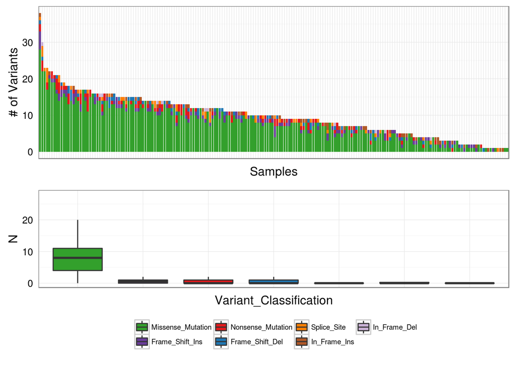

```r
plotmafSummary(laml)
```

## oncoplot to summarize maf file

`oncoplot` This function uses slightly modified [oncoprint](https://github.com/jokergoo/ComplexHeatmap/blob/908b32ee4c495c74adfa077c967024a77c56b375/vignettes/oncoprint.R) script from ComplexHeatmap package by [Zuguang Gu](https://github.com/jokergoo), while taking care of format conversions and with some added fucntionalities.

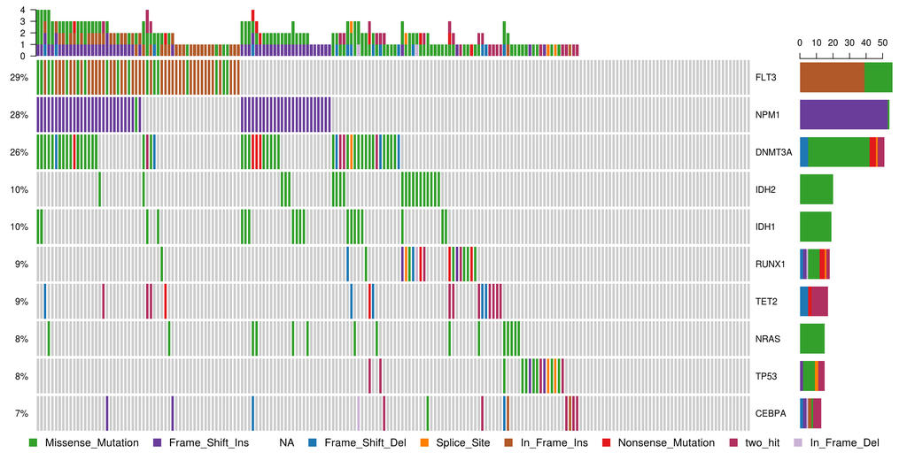

```r
#We will plot top ten mutated genes
oncoplot(maf = laml, top = 10)
```

## Adding annotations to oncoplot

We can add annotations to the bottom of the plot.

```r
#Read FAB classification of TCGA LAML barodes.
laml.fab.anno = system.file('extdata', 'tcga_laml_fab_annotation.txt', package = 'maftools')
laml.fab.anno = read.delim(laml.fab.anno, sep = '\t')
head(laml.fab.anno)
```

```
##   bcr_patient_barcode fab_category
## 1        TCGA-AB-2802           M4
## 2        TCGA-AB-2803           M3
## 3        TCGA-AB-2804           M3
## 4        TCGA-AB-2805           M0
## 5        TCGA-AB-2806           M1
## 6        TCGA-AB-2807           M1
```

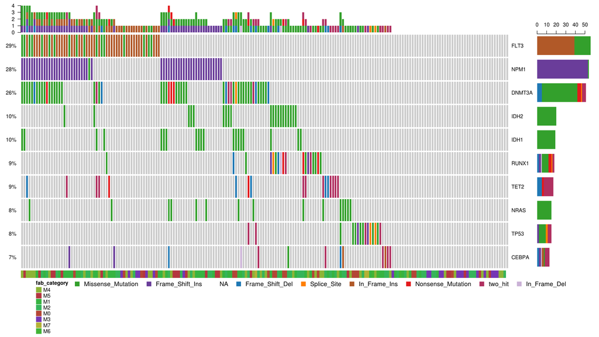

```r
#We will plot same top ten mutated genes with FAB classification as annotation.
oncoplot(maf = laml, top = 10, annotation = laml.fab.anno)
```

## oncoprint

`oncoprint` draws a matrix similar to [oncoprint](http://www.cbioportal.org/faq.jsp#what-are-oncoprints) on [cBioPortal](http://www.cbioportal.org/index.do).

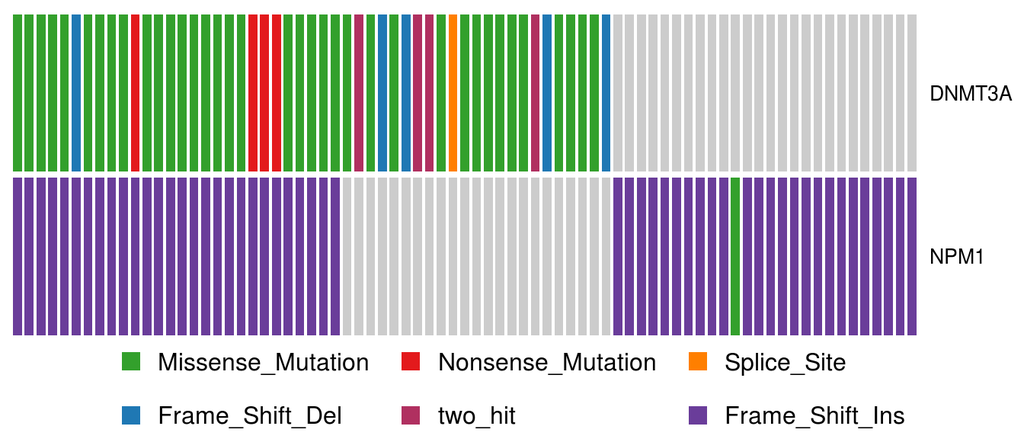

```r
oncoprint(maf = laml, genes = c('DNMT3A', 'NPM1'), sort = T, legend = T, removeNonMutated = T)
```

Use arguments drawRowBar, drawColBar to control side and upper barplots.

## Classify SNVs into Trasitions and Transversions

Each Single Nucleotide Variant can be classified into Trasition or Transversion. Variants can also be divided into six different classes, which helps to know us which kind of conversions are more frequent in a given type of cancer.

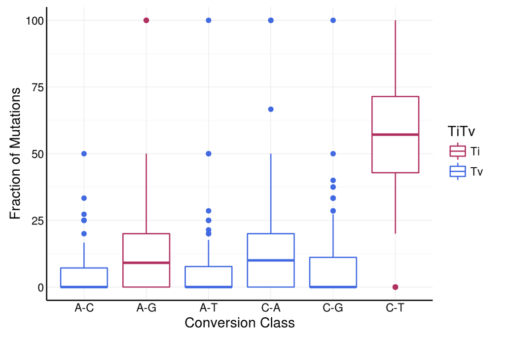

```r
laml.titv.summary = titv(maf = laml, plot = T)
```

It also returns a list of dataframes with raw counts for each conversion, fraction of each conversion and Ti to Tv ratios.

## Annotating variants with Oncotator

We can also annotate variants using [oncotator](http://www.broadinstitute.org/oncotator/) API.

```r
var.file = system.file('extdata', 'variants.tsv', package = 'maftools')
#This is what input looks like
var = read.delim(var.file, sep = '\t')
head(var)
```

```
##   chromsome    start      end     ref alt Tumor_Sample_Barcode
## 1      chr4 55589774 55589774       A   G               fake_1
## 2      chr4 55599321 55599321       A   T               fake_2
## 3      chr4 55599332 55599332       G   T               fake_3
## 4      chr4 55599320 55599320       G   T               fake_4
## 5     chr15 41961117 41961123 TGGCTAA   -               fake_4
## 6      chr4 55599320 55599320       G   T               fake_5
```

```r
#Annotate
var.maf = oncotate(maflite = var.file, header = T)
```

```
## fetching annotation from Oncotator. This might take a while..
```

This is quite time consuming if input is big.

## Mutual Exclusivity

Many genes in cancer show strong exclusiveness in mutation pattern. We can detect such pair of genes using `mutExclusive` which runs `comet_exact_test` from `cometExactTest` package for significance.

```r
mutExclusive(maf = laml, genes = c('NPM1', 'RUNX1'))
```

```
##   n.00 n.01 n.10 n.11 gene1 gene2                pval
## 1  124   18   54    0  NPM1 RUNX1 0.00109823009964897
```

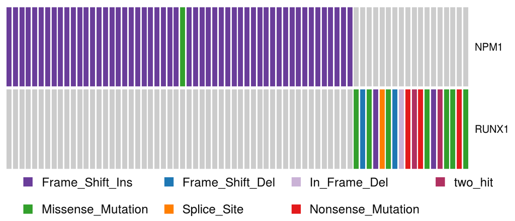

```r
#We can visualize this pair using oncoprint
oncoprint(maf = laml, genes = c('NPM1', 'RUNX1'), sort = T, legend = T, removeNonMutated = T)
```

## Extract adjacent bases

One can also extract n number of adjacent (3’ and 5’) bases to the mutated locus using `addBases`. This is helpful in looking for [somatic-signatures](http://cancer.sanger.ac.uk/cosmic/signatures). This requires faidx indexed reference genome (fasta file).

## Add read count and allele frequencies to maf.

`addReadCounts()` adds read depths for reference and alternate allele from corresponding bam file. This internally runs bam-readcount to get the counts and adds them to maf file.